# 🏛️ 민원 텍스트 분류 및 정부 부처 추천 시스템

## 🧾 프로젝트 정보

- **진행기간**: 2025.02 ~ 2025.04
- **참여 형태**: 개인 프로젝트
- **프로젝트 개요**: 사용자가 입력한 민원 텍스트를 18개 카테고리로 분류하는 자연어 처리 시스템 전이학습 기반의 한국어 BERT 계열 모델들을 비교 실험하여 최적 성능의 분류 모델을 도출하고 예측된 카테고리에 맞는 중앙정부 부처의 **홈페이지 및 대표 전화번호 정보를 제공**하는 기능을 포함하고 있음.

## 🛠 사용 기술

### 📦 프레임워크 & 라이브러리

- Transformers (HuggingFace)
- PyTorch
- Pandas / Numpy
- Matplotlib / Seaborn
- Scikit-learn

### 💻 개발 환경

- Python
- Jupyter Notebook
- VSCode

## 📂 데이터셋 정보

- **출처**: AIHub의 [민원 업무 자동화 인공지능 언어 데이터](https://www.aihub.or.kr/aihubdata/data/view.do?currMenu=115&topMenu=100&dataSetSn=619) 사용
- **형식**: JSON (`원천데이터`, `라벨링데이터`로 분리 제공)
- **구성요소**:
  - 원천데이터: `id`, `text`
  - 라벨링데이터: `id`, `category`, `subcategory`, `prediction`, `department`, `Q_refined`... 외 다수
- **JSON -> 필요한 컬럼 추출 및 형태 변환(csv)**
  - 원천데이터_train/val.csv
  - 라벨링데이터_train/val.csv
- **최종 학습셋**(데이터 전처리)
  - 민원통합데이터_train.csv
  - 민원통합데이터_val.csv

⚠️ 본 프로젝트는 머신러닝/딥러닝 기반으로 구현되었으며,  
모델 학습 시 초기 가중치, 데이터 셔플링, 실행 환경 등에 따라 결과가 소폭 달라질 수 있습니다.  
따라서 실행 시 출력되는 성능 수치나 시각화 결과는 본 문서에 기재된 내용과 일부 차이가 발생할 수 있습니다.

## 📄 데이터 추출 및 형태 변환

### ✅ 처리 과정

1. **라벨링 데이터**
   - 각 문서에서 `id`, `labeling.intent.category` 추출 → CSV로 저장
2. **원천 데이터**
   - 각 문서에서 `id`, `Q_refined` 추출 → CSV로 저장
3. **glob + 재귀 탐색**을 통해 모든 하위 JSON 파일 자동 수집
4. **id 기준 데이터 병합**을 위한 사전 준비 단계로 사용

```python
import os
import glob
import json
import pandas as pd

def parse_documents(f):
    data = json.load(open(f, encoding='utf-8'))
    return data['documents'] if isinstance(data, dict) and 'documents' in data else data

def extract_labeling_data(files):
    return pd.DataFrame([
        {'id': d.get('id', ''), 'category': d.get('labeling', {}).get('intent', {}).get('category', '')}
        for f in files
        for d in parse_documents(f)
    ])

def extract_raw_data(files):
    return pd.DataFrame([
        {'id': d.get('id', ''), 'text': d.get('Q_refined', '')}
        for f in files
        for d in parse_documents(f)
    ])

if __name__ == '__main__':
    base = 'dataset'
    paths = {
        '라벨링데이터_train.csv': glob.glob(f'{base}/1.Training/라벨링데이터/**/*.json', recursive=True),
        '원천데이터_train.csv': glob.glob(f'{base}/1.Training/원천데이터/**/*.json', recursive=True),
        '라벨링데이터_val.csv': glob.glob(f'{base}/2.Validation/라벨링데이터/**/*.json', recursive=True),
        '원천데이터_val.csv': glob.glob(f'{base}/2.Validation/원천데이터/**/*.json', recursive=True),
    }
    for name, files in paths.items():
        df = extract_labeling_data(files) if '라벨링' in name else extract_raw_data(files)
        df.to_csv(name, index=False, encoding='utf-8')
```

```python
import pandas as pd
df_org_train = pd.read_csv('원천데이터_train.csv')
df_org_val = pd.read_csv('원천데이터_val.csv')
df_lb_train = pd.read_csv('라벨링데이터_train.csv')
df_lb_val = pd.read_csv('라벨링데이터_val.csv')
```

```python
df_org_train.shape
```

```
(800000, 2)
```

```python
df_org_val.shape
```

```
(100000, 2)
```

```python
df_lb_train.shape
```

```
(800000, 2)
```

```python
df_lb_val.shape
```

```
(100000, 2)
```

```python
df_org_train.describe()
```

|  | id | text |
| --- | --- | --- |
| count | 800000 | 800000 |
| unique | 800000 | 692376 |
| top | C49922-4 | 횡단보도 불법 주정차 차량 신고입니다. |
| freq | 1 | 905 |

```python
df_lb_train.describe()
```

|  | id | category |
| --- | --- | --- |
| count | 800000 | 800000 |
| unique | 800000 | 18 |
| top | C49922-4 | 자동차 |
| freq | 1 | 295107 |

## 🔍 병합 전 ID 매칭 확인 과정

병합 전에 **원천데이터와 라벨링데이터 간의 ID가 일치하는지 확인**하는 과정입니다.

### ✅ 목적

- `원천데이터(id, text)`와 `라벨링데이터(id, category)`를 병합하기 위해,
- 공통된 `id`가 실제로 **양쪽에 모두 존재하는지** 시각적으로 확인

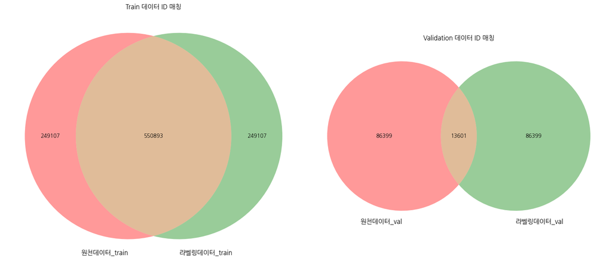

```python
import matplotlib.pyplot as plt
from matplotlib_venn import venn2

train_org_ids = set(df_org_train["id"].unique())
train_lb_ids  = set(df_lb_train["id"].unique())
val_org_ids   = set(df_org_val["id"].unique())
val_lb_ids    = set(df_lb_val["id"].unique())

fig, axes = plt.subplots(1, 2, figsize=(16, 8))

venn2([train_org_ids, train_lb_ids],
      set_labels=("원천데이터_train", "라벨링데이터_train"),
      ax=axes[0])
axes[0].set_title("Train 데이터 ID 매칭")

venn2([val_org_ids, val_lb_ids],
      set_labels=("원천데이터_val", "라벨링데이터_val"),
      ax=axes[1])
axes[1].set_title("Validation 데이터 ID 매칭")

plt.tight_layout()
plt.show()
```

## 🔗 원천데이터 + 라벨링데이터 병합

- `id` 기준으로 원천데이터(`text`)와 라벨링데이터(`category`)를 하나로 결합하여 정합성 확보

```python
df_merged_train = pd.merge(df_org_train, df_lb_train, on='id')[['id', 'text', 'category']]
df_merged_val = pd.merge(df_org_val, df_lb_val, on='id')[['id', 'text', 'category']]
```

```python
df_merged_train.head()
```

|  | id | text | category |
| --- | --- | --- | --- |
| 0 | B10-3 | 창원시 의창구 #@주소#에 불법건축물 제발 조치해주시기 바랍니다. | 건축허가 |
| 1 | B10-4 | 창원시 의창구 #@주소#에 불법건축물에 대해 법적 조치 요청합니다. | 건축허가 |
| 2 | B12-1 | 경남 창원시 마산회원구 #@주소# 삼거리에 불법으로 부착된 현수막이 10개 가까이 ... | 건축허가 |
| 3 | B12-2 | 경남 창원시 마산회원구 #@주소# 삼거리에 불법으로 부착된 현수막이 10개 가까이 ... | 건축허가 |
| 4 | B12-3 | 경남 창원시 마산회원구 #@주소# 삼거리에 불법으로 부착된 현수막이 10개 가까이 ... | 건축허가 |

```python
df_merged_val.head()
```

|  | id | text | category |
| --- | --- | --- | --- |
| 0 | C27567-2 | 진해구 충장로 거주지 근처 자동차 정비공장이 길을 내면서 구청의 허가가 있었다고 합... | 농업_축산 |
| 1 | B102020-2 | 창원시 #@주소# 관리실 앞에 광려천 다리가 어두워서 보행자들이 위험합니다. 가로등... | 공통 |
| 2 | B102033-2 | 경상남도 창원시 마산회원구 #@주소# 옆 공사자재를 주차라인에 놔둬서 주차공간 부족... | 공통 |
| 3 | B102066-2 | #@주소#, 자전거전용도로 단절에 대한 답변과 관련하여 담당 부서 담당자들은 거짓 ... | 공통 |
| 4 | B102088-2 | 진해 #@주소# 마리나 방파제에서의 낚시금지를 풀어주시고 적절한 관리 요청드립니다. | 공통 |

```python
df_merged_train.describe()
```

|  | id | text | category |
| --- | --- | --- | --- |
| count | 550893 | 550893 | 550893 |
| unique | 550893 | 481833 | 18 |
| top | C49988-4 | 창원시 성산구 장애인 전용구역 불법 주정차 조치해주세요. | 자동차 |
| freq | 1 | 266 | 216164 |

```python
df_merged_val.describe()
```

|  | id | text | category |
| --- | --- | --- | --- |
| count | 13601 | 13601 | 13601 |
| unique | 13601 | 13209 | 8 |
| top | C5210-2 | 창원 횡단보도 불법 주정차 신고 드려요. | 교통 |
| freq | 1 | 86 | 6916 |

## 🧹 중복 텍스트 제거 및 정제

### ✅ 목적

- 데이터셋 내에 **동일한 `text` 값이 여러 번 등장하는 경우**,
- 텍스트 분류 모델의 학습 품질 저하 및 데이터 편향을 방지하기 위해 **중복을 제거.**

### 🔍 중복 제거 기준

1. **`text`가 동일한 행**들을 그룹화
2. 해당 그룹 내 **`category`가 하나라면 그대로 유지**
3. **여러 `category`가 존재할 경우**,  
   → **최빈값(Most Frequent Category)** 기준으로 대표 행 1개만 남김

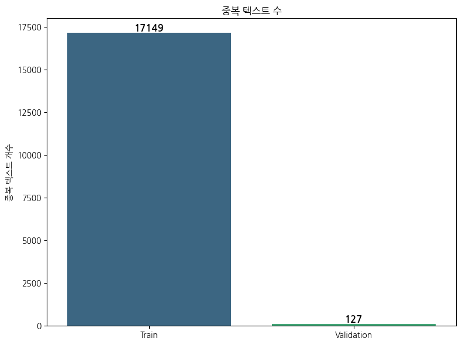

```python
import seaborn as sns

train_counts = df_merged_train.groupby("text").size().reset_index(name="count")
val_counts   = df_merged_val.groupby("text").size().reset_index(name="count")

train_dup_count = (train_counts["count"] >= 2).sum()
val_dup_count   = (val_counts["count"] >= 2).sum()

data = pd.DataFrame({
    "Dataset": ["Train", "Validation"],
    "Duplicate_Text_Count": [train_dup_count, val_dup_count]
})

plt.figure(figsize=(8, 6))
ax = sns.barplot(x="Dataset", y="Duplicate_Text_Count", data=data, palette="viridis")

for patch in ax.patches:
    height = patch.get_height()
    ax.text(
        patch.get_x() + patch.get_width() / 2,
        height,
        f'{height:.0f}',
        ha='center',
        va='bottom',
        fontsize=12,
        color='black',
        weight='bold'
    )

plt.title("중복 텍스트 수")
plt.ylabel("중복 텍스트 개수")
plt.xlabel("")
plt.tight_layout()
plt.show()
```

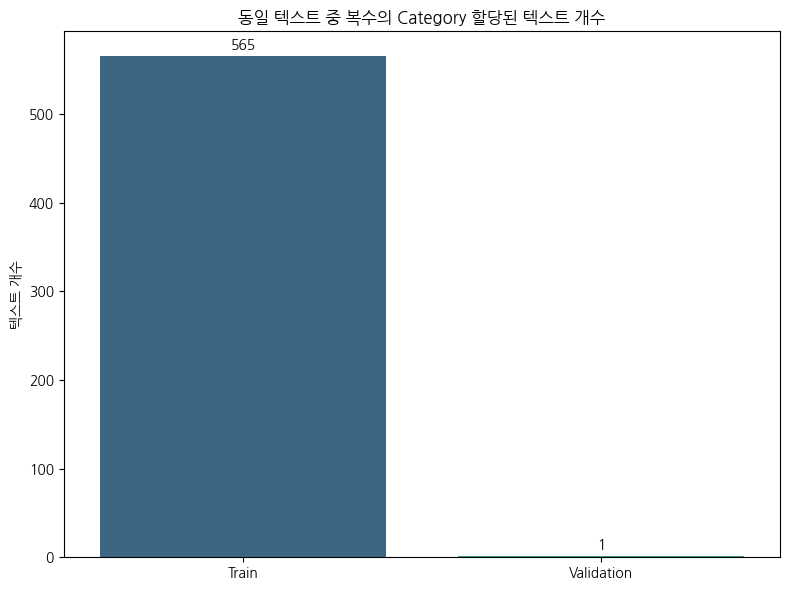

```python
import pandas as pd
import matplotlib.pyplot as plt
import seaborn as sns

train_grouped = df_merged_train.groupby("text")["category"].nunique()
train_dup = (train_grouped >= 2).sum()

val_grouped = df_merged_val.groupby("text")["category"].nunique()
val_dup = (val_grouped >= 2).sum()

data = pd.DataFrame({
    "Dataset": ["Train", "Validation"],
    "Duplication_Count": [train_dup, val_dup]
})

plt.figure(figsize=(8,6))
ax = sns.barplot(x="Dataset", y="Duplication_Count", data=data, palette="viridis")

for container in ax.containers:
    ax.bar_label(container, fmt="%.0f", padding=3)

plt.title("동일 텍스트 중 복수의 Category 할당된 텍스트 개수")
plt.ylabel("텍스트 개수")
plt.xlabel("")
plt.tight_layout()
plt.show()
```

```python
import pandas as pd

def deduplicate_text_with_mode_category(df):
    def get_representative(group):
        mode = group['category'].mode()
        return group[group['category'] == mode.iloc[0]].iloc[0]

    return df.groupby('text', group_keys=False).apply(get_representative)

# 중복 제거
df_merged_train = deduplicate_text_with_mode_category(df_merged_train)
df_merged_train = deduplicate_text_with_mode_category(df_merged_val)
```

## 🧮 학습/검증 데이터셋 비율 확인

### ✅ 목적

- 전체 데이터 중 **Train / Validation 셋의 비율이 적절한지 확인.**

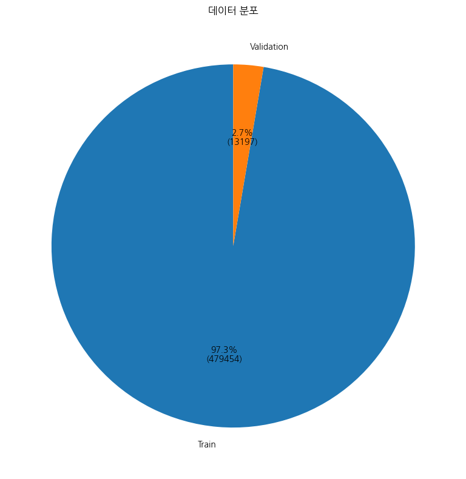

```python
import np

train_count = len(df_merged_train)
val_count = len(df_merged_val)

counts = [train_count, val_count]
labels = ["Train", "Validation"]

def make_autopct(values):
    def my_autopct(pct):
        absolute = int(round(pct/100. * np.sum(values)))
        return "{:.1f}%\n({:d})".format(pct, absolute)
    return my_autopct

plt.figure(figsize=(8,8))
plt.pie(counts, labels=labels, autopct=make_autopct(counts), startangle=90)
plt.title("데이터 분포")
plt.tight_layout()
plt.show()
```

## 🔧 데이터셋 비율 조정 (Train / Validation)

### ✅ 문제 상황

- 전처리 과정(정합성 확보, 정제, 중복 제거)을 거친 후,  
  전체 데이터의 분포가 **Train 97.3%, Validation 2.7%**로 심하게 불균형함.

### 🔁 비율 조정

- **Train 데이터에서 10%를 분리하여 Validation 데이터에 병합**
- 이때 각 `category`의 비율이 유지되도록 → **Stratified Sampling** 사용

```python
import pandas as pd
from sklearn.model_selection import train_test_split

train_90, train_10 = train_test_split(
    df_train,
    test_size=0.10,
    stratify=df_train['category'],
)

df_merged_val = pd.concat([df_merged_val, train_10], ignore_index=True)

train_90.to_csv('민원통합데이터_train.csv', index=False, encoding='utf-8')
df_merged_val.to_csv('민원통합데이터_val.csv', index=False, encoding='utf-8')
```

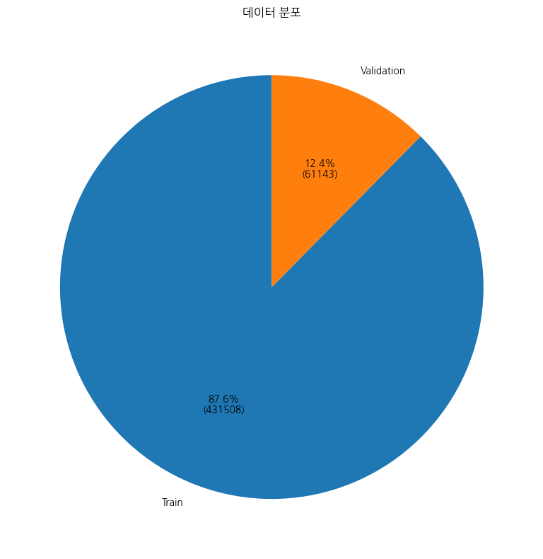

```python
import numpy as np

df_train = pd.read_csv("민원통합데이터_train.csv")
df_val   = pd.read_csv("민원통합데이터_val.csv")

train_count = len(df_train)
val_count = len(df_val)

counts = [train_count, val_count]
labels = ["Train", "Validation"]

def make_autopct(values):
    def my_autopct(pct):
        absolute = int(round(pct/100. * np.sum(values)))
        return "{:.1f}%\n({:d})".format(pct, absolute)
    return my_autopct

plt.figure(figsize=(8,8))
plt.pie(counts, labels=labels, autopct=make_autopct(counts), startangle=90)
plt.title("데이터 분포")
plt.tight_layout()
plt.show()
```

## 📊 데이터 분포 확인

### ✅ 목적

- 분류 모델 학습 전, 각 `category` 클래스가 얼마나 고르게 분포되어 있는지 확인.
- 클래스 간 불균형이 심할 경우 모델이 특정 클래스에 편향될 수 있으므로 사전 확인.

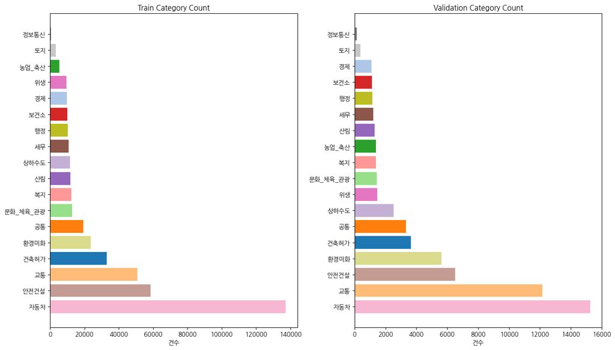

```python
import pandas as pd
import matplotlib.pyplot as plt
import matplotlib.font_manager as fm

train_counts = df_train["category"].value_counts()
val_counts = df_val["category"].value_counts()

all_categories = sorted(set(train_counts.index) | set(val_counts.index))
color_palette = plt.cm.tab20.colors
color_map = {cat: color_palette[i % len(color_palette)] for i, cat in enumerate(all_categories)}
train_colors = [color_map[cat] for cat in train_counts.index]
val_colors = [color_map[cat] for cat in val_counts.index]

fig, axes = plt.subplots(1, 2, figsize=(14, 8))

axes[0].barh(train_counts.index, train_counts.values, color=train_colors)
axes[0].set_title("Train Category Count")
axes[0].set_xlabel("건수")

axes[1].barh(val_counts.index, val_counts.values, color=val_colors)
axes[1].set_title("Validation Category Count")
axes[1].set_xlabel("건수")

plt.tight_layout()
plt.show()
```

## ⚡️ LightGBM 기반 Baseline 성능 평가

### ✅ 목적

- 전처리 및 중복 제거된 데이터를 기반으로  
  **LightGBM 모델을 사용해 텍스트 분류 성능을 빠르게 확인.**
- 딥러닝 모델과 비교하기 위한 **Baseline 성능 지표**로 활용.

### 🔄 처리 흐름

1. **TF-IDF 벡터화**를 통해 텍스트(`text`)를 수치형 벡터로 변환
2. **LightGBM 모델** 학습
3. 검증 데이터셋에 대해 예측 및 성능 평가
- LightGBM은 빠른 성능 확인에 적합한 **Baseline 모델**로서,  
  전체적인 경향 파악에 유용함

[output not shown]

[output cut: 5370 more lines]

[output not shown]

```
✅ 정확도: 0.6151

📊 분류 리포트:
              precision    recall  f1-score   support

        건축허가       0.56      0.58      0.57      3659
          경제       0.58      0.46      0.51      1102
          공통       0.33      0.15      0.20      3344
          교통       0.62      0.52      0.57     12158
       농업_축산       0.68      0.50      0.57      1386
    문화_체육_관광       0.45      0.37      0.40      1448
         보건소       0.59      0.53      0.56      1112
          복지       0.51      0.45      0.48      1389
          산림       0.43      0.38      0.41      1306
        상하수도       0.75      0.64      0.69      2518
          세무       0.78      0.79      0.78      1199
        안전건설       0.42      0.66      0.52      6519
          위생       0.59      0.57      0.58      1462
         자동차       0.75      0.91      0.82     15246
        정보통신       0.00      0.00      0.00       147
          토지       0.31      0.32      0.31       379
          행정       0.32      0.31      0.31      1152
        환경미화       0.74      0.57      0.65      5617

    accuracy                           0.62     61143
   macro avg       0.52      0.48      0.50     61143
weighted avg       0.61      0.62      0.60     61143
```

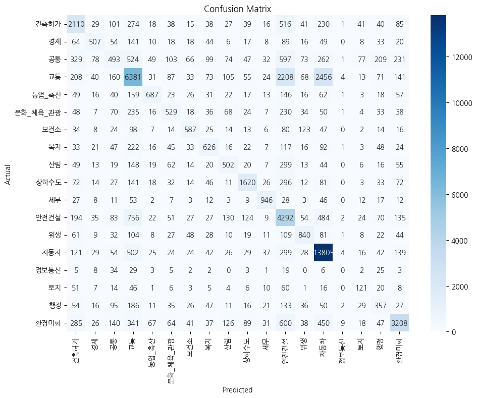

```python
import pandas as pd
from sklearn.feature_extraction.text import TfidfVectorizer
from sklearn.preprocessing import LabelEncoder
from lightgbm import LGBMClassifier
from sklearn.metrics import accuracy_score, classification_report, confusion_matrix
import matplotlib.pyplot as plt
import seaborn as sns

# 데이터 로딩
df_train = pd.read_csv("민원통합데이터_train.csv")
df_val = pd.read_csv("민원통합데이터_val.csv")

# 텍스트와 라벨 추출
X_train = df_train["text"]
y_train = df_train["category"]
X_val = df_val["text"]
y_val = df_val["category"]

# 라벨 인코딩
le = LabelEncoder()
y_train_enc = le.fit_transform(y_train)
y_val_enc = le.transform(y_val)

# TF-IDF 벡터화
vectorizer = TfidfVectorizer(max_features=50000, ngram_range=(1, 2))
X_train_vec = vectorizer.fit_transform(X_train)
X_val_vec = vectorizer.transform(X_val)

# LightGBM 분류기
model = LGBMClassifier(random_state=42, n_estimators=300, learning_rate=0.1, n_jobs=-1, verbose=100)
model.fit(X_train_vec, y_train_enc)

# 예측 및 평가
y_pred = model.predict(X_val_vec)
acc = accuracy_score(y_val_enc, y_pred)
print(f"\n✅ 정확도: {acc:.4f}\n")

# 상세 리포트
print("📊 분류 리포트:")
print(classification_report(y_val_enc, y_pred, target_names=le.classes_))

# 혼동 행렬
plt.figure(figsize=(10, 8))
cm = confusion_matrix(y_val_enc, y_pred)
sns.heatmap(cm, annot=True, fmt='d', cmap="Blues",
            xticklabels=le.classes_, yticklabels=le.classes_)
plt.title("Confusion Matrix")
plt.xlabel("Predicted")
plt.ylabel("Actual")
plt.xticks(rotation=90)
plt.yticks(rotation=0)
plt.tight_layout()
plt.show()
```

### 📊 성능 요약

- **Accuracy (정확도)**: `0.6151`
- **Macro F1-Score**: `0.50`
- **Weighted F1-Score**: `0.60`
- 전체적으로 **중간 수준의 정확도**를 보였으며 클래스 불균형이 있는 상황에서도 일정 수준의 성능을 보여줌

### 📉 클래스별 성능 분석

- 성능이 **우수한 클래스**:
  - `자동차` (F1: 0.82) → 데이터 수가 많고 텍스트 특성이 명확
  - `세무`, `상하수도`, `환경미화` 등도 비교적 안정적
- 성능이 **낮은 클래스**:
  - `정보통신`, `공통`, `행정`, `토지` → 데이터 수가 적거나 표현이 모호하여 낮은 F1
- 특히 `정보통신`은 **precision/recall 모두 0**으로 **완전 분류 실패**

### 🧭 혼동 행렬 해석

- 클래스 간 혼동이 높은 경우 다수 존재
  - 예: `교통` ↔ `자동차`, `안전건설` ↔ `교통`
- 일부 클래스는 **다양한 다른 클래스로 잘못 예측**됨 (`공통`, `건축허가` 등)

## 🧠 SKT KoBERT 분류 성능 평가

### ✅ 모델 정보

- **모델**: `skt/kobert-base-v1`
- **입력 길이**: max length = 256
- **Token Type IDs**: 모두 0 처리 (KoBERT 호환성 고려)
- **학습 방식**: Hugging Face `Trainer` + EarlyStopping

```python
import os
os.environ["CUDA_LAUNCH_BLOCKING"] = "1"

import pandas as pd
import numpy as np
import torch
from sklearn.preprocessing import LabelEncoder
from sklearn.metrics import accuracy_score, classification_report
from datasets import Dataset
from transformers import (
    AutoTokenizer,
    AutoModelForSequenceClassification,
    Trainer,
    TrainingArguments,
    EarlyStoppingCallback
)

# 1. 데이터 로딩 및 라벨 인코딩 (컬럼명: labels)
def load_and_encode_data(train_path, val_path):
    df_train = pd.read_csv(train_path)
    df_val = pd.read_csv(val_path)

    le = LabelEncoder()
    df_train['labels'] = le.fit_transform(df_train['category'])
    df_val['labels'] = le.transform(df_val['category'])

    return df_train, df_val, le

# 토크나이징 함수
def tokenize_dataset(dataset, tokenizer):
    def tokenize_fn(batch):
        out = tokenizer(batch['text'], padding='max_length', truncation=True, max_length=256)
        if "token_type_ids" in out:
            out["token_type_ids"] = [[0] * len(ids) for ids in out["input_ids"]]
        return out

    return dataset.map(tokenize_fn, batched=True)

# 평가 메트릭 함수
def compute_metrics(eval_pred):
    logits, labels = eval_pred
    preds = np.argmax(logits, axis=-1)
    return {"accuracy": accuracy_score(labels, preds)}

# 메인 실행 함수
def main():
    model_name = "skt/kobert-base-v1"

    # 데이터 로딩 및 라벨 인코딩
    df_train, df_val, le = load_and_encode_data("민원통합데이터_train.csv", "민원통합데이터_val.csv")

    # HuggingFace Dataset 변환
    dataset_train = Dataset.from_pandas(df_train[["text", "labels"]])
    dataset_val = Dataset.from_pandas(df_val[["text", "labels"]])

    # 토크나이저 및 토큰화
    tokenizer = AutoTokenizer.from_pretrained(model_name, use_fast=False)
    tokenized_train = tokenize_dataset(dataset_train, tokenizer)
    tokenized_val = tokenize_dataset(dataset_val, tokenizer)

    # 모델 로딩
    model = AutoModelForSequenceClassification.from_pretrained(model_name, num_labels=len(le.classes_))

    # 학습 설정
    training_args = TrainingArguments(
        output_dir="./kobert-results",
        evaluation_strategy="epoch",
        save_strategy="epoch",
        learning_rate=2e-5,
        per_device_train_batch_size=64,
        per_device_eval_batch_size=64,
        num_train_epochs=100,
        weight_decay=0.01,
        load_best_model_at_end=True,
        metric_for_best_model="eval_loss",
        greater_is_better=False,
        logging_dir="./kobert-logs",
        fp16=torch.cuda.is_available(),
        dataloader_num_workers=4
    )

    # Trainer 생성
    trainer = Trainer(
        model=model,
        args=training_args,
        train_dataset=tokenized_train,
        eval_dataset=tokenized_val,
        tokenizer=tokenizer,
        compute_metrics=compute_metrics,
        callbacks=[EarlyStoppingCallback(early_stopping_patience=10)]
    )

    # 학습
    trainer.train()

    # 모델 저장
    model.save_pretrained("./kobert_final_model")
    tokenizer.save_pretrained("./kobert_final_model")

    # 예측
    preds_output = trainer.predict(tokenized_val)
    pred_labels = np.argmax(preds_output.predictions, axis=-1)

    # 결과 저장
    result_df = pd.DataFrame({
        "text": df_val["text"],
        "true_label": df_val["category"],
        "pred_label": le.inverse_transform(pred_labels)
    })
    result_df.to_csv("kobert_val_predictions.csv", index=False, encoding="utf-8")

    # 평가 출력
    print(f"\n✅ Accuracy: {accuracy_score(df_val['labels'], pred_labels):.4f}")
    print("\n📊 Classification Report:")
    print(classification_report(df_val['labels'], pred_labels, target_names=le.classes_))

if __name__ == "__main__":
    main()
```

```
Some weights of BertForSequenceClassification were not initialized from the model checkpoint at skt/kobert-base-v1 and are newly initialized: ['classifier.bias', 'classifier.weight']
You should probably TRAIN this model on a down-stream task to be able to use it for predictions and inference.
```

[155089/674300 13:02:10 < 43:38:37, 3.30 it/s, Epoch 23/100]

| Epoch | Training Loss | Validation Loss | Accuracy |
| --- | --- | --- | --- |
| 1 | 0.684200 | 0.739964 | 0.767610 |
| 2 | 0.566700 | 0.603859 | 0.808629 |
| 3 | 0.444100 | 0.516594 | 0.838183 |
| 4 | 0.344800 | 0.449975 | 0.862306 |
| 5 | 0.275100 | 0.380816 | 0.890159 |
| 6 | 0.222600 | 0.359017 | 0.901428 |
| 7 | 0.178100 | 0.309525 | 0.917390 |
| 8 | 0.143600 | 0.304531 | 0.921872 |
| 9 | 0.123800 | 0.308407 | 0.924439 |
| 10 | 0.107200 | 0.303550 | 0.928888 |
| 11 | 0.095800 | 0.307889 | 0.931194 |
| 12 | 0.082700 | 0.296357 | 0.936248 |
| 13 | 0.073800 | 0.291952 | 0.938358 |
| 14 | 0.066900 | 0.315784 | 0.936509 |
| 15 | 0.058600 | 0.314699 | 0.939045 |
| 16 | 0.056400 | 0.319424 | 0.939094 |
| 17 | 0.052700 | 0.327458 | 0.941825 |
| 18 | 0.050800 | 0.324782 | 0.941138 |
| 19 | 0.049200 | 0.324592 | 0.942299 |
| 20 | 0.043000 | 0.338694 | 0.941580 |
| 21 | 0.036700 | 0.337842 | 0.943428 |
| 22 | 0.036600 | 0.335538 | 0.946780 |
| 23 | 0.036300 | 0.341094 | 0.946323 |

```
✅ Accuracy: 0.9384

📊 Classification Report:
              precision    recall  f1-score   support

        건축허가       0.93      0.92      0.93      3659
          경제       0.92      0.95      0.93      1102
          공통       0.87      0.84      0.85      3344
          교통       0.94      0.93      0.94     12158
       농업_축산       0.98      0.95      0.97      1386
    문화_체육_관광       0.94      0.92      0.93      1448
         보건소       0.90      0.95      0.93      1112
          복지       0.93      0.94      0.93      1389
          산림       0.87      0.87      0.87      1306
        상하수도       0.96      0.98      0.97      2518
          세무       0.98      0.96      0.97      1199
        안전건설       0.91      0.93      0.92      6519
          위생       0.94      0.90      0.92      1462
         자동차       0.96      0.98      0.97     15246
        정보통신       0.97      0.87      0.92       147
          토지       0.91      0.82      0.87       379
          행정       0.84      0.87      0.85      1152
        환경미화       0.96      0.95      0.95      5617

    accuracy                           0.94     61143
   macro avg       0.93      0.92      0.92     61143
weighted avg       0.94      0.94      0.94     61143
```

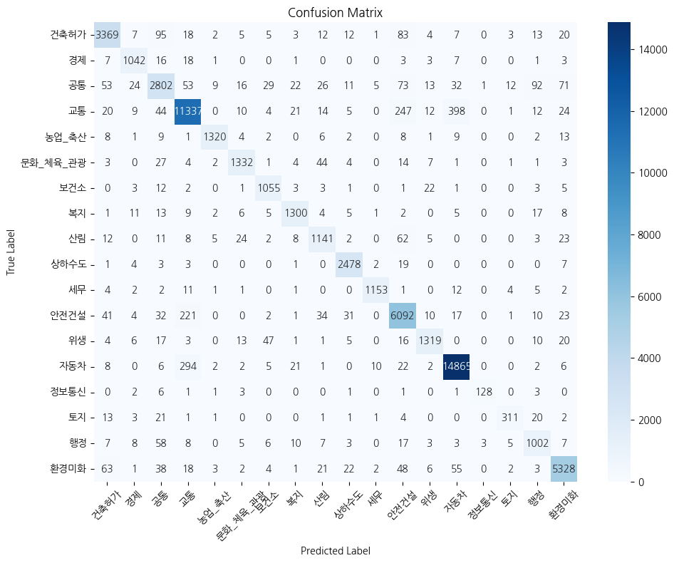

```python
df_pred = pd.read_csv("kobert_val_predictions.csv", encoding="utf-8")

y_true = df_pred["true_label"].values
y_pred = df_pred["pred_label"].values

labels = sorted(list(set(y_true) | set(y_pred)))

# 혼동 행렬 계산
cm = confusion_matrix(y_true, y_pred, labels=labels)

# 혼동 행렬 시각화
plt.figure(figsize=(10, 8))
sns.heatmap(cm, annot=True, fmt="d", cmap="Blues", xticklabels=labels, yticklabels=labels)
plt.xlabel("Predicted Label")
plt.ylabel("True Label")
plt.title("Confusion Matrix")
plt.xticks(rotation=45)
plt.yticks(rotation=0)
plt.tight_layout()
plt.show()
```

### 📊 클래스별 성능 분석

- **F1-score 0.90 이상**: `자동차`, `교통`, `세무`, `환경미화`, `상하수도` 등
- **소수 클래스도 높은 성능 유지**:
  - `정보통신`: F1 = 0.92
  - `토지`: F1 = 0.87
- **전체적으로 recall과 precision 간 균형이 우수**, 데이터 편향 문제 없음

### 🧾 혼동 행렬 해석

- 대부분의 클래스에서 **정확하게 대각선 상에 예측**됨
- 클래스 간 혼동이 거의 없고, 일부 유사 클래스(예: `공통`, `행정`)만 소량의 오차 존재

### 📌 종합 평가

| 항목 | 결과 |
| --- | --- |
| Accuracy | 0.9384 |
| Macro F1 | 0.92 |
| 모델 크기 | base |
| 인코딩 방식 | 토큰 + attention mask (token_type_ids = 0) |
| 활용 가능성 | ✅ 실제 서비스 수준으로 적용 가능한 성능 |

## 🤖 KLUE RoBERTa 분류 성능 평가

### ✅ 모델 정보

- **모델**: `klue/roberta-base`
- **입력 길이**: max length = 128
- **Token Type IDs**: 사용하지 않음 (RoBERTa 계열 구조)
- **학습 방식**: Hugging Face `Trainer` + EarlyStopping
- **데이터 인코딩**: 라벨 → `labels` 컬럼명, tokenizer → truncation 방식

```python
import os
os.environ["CUDA_LAUNCH_BLOCKING"] = "1"

import pandas as pd
import numpy as np
import torch
from sklearn.preprocessing import LabelEncoder
from sklearn.metrics import accuracy_score, classification_report
from datasets import Dataset
from transformers import (
    AutoTokenizer,
    AutoModelForSequenceClassification,
    Trainer,
    TrainingArguments,
    DataCollatorWithPadding,
    EarlyStoppingCallback
)

# 데이터 로딩 및 인코딩 (컬럼명: labels)
def load_and_encode_data(train_path, val_path):
    df_train = pd.read_csv(train_path)
    df_val = pd.read_csv(val_path)

    le = LabelEncoder()
    df_train['labels'] = le.fit_transform(df_train['category'])
    df_val['labels'] = le.transform(df_val['category'])

    return df_train, df_val, le

# 토크나이징 함수
def tokenize_dataset(dataset, tokenizer):
    def tokenize_fn(batch):
        return tokenizer(batch['text'], truncation=True, max_length=128)
    return dataset.map(tokenize_fn, batched=True)

# 평가 함수
def compute_metrics(eval_pred):
    logits, labels = eval_pred
    preds = np.argmax(logits, axis=-1)
    return {"accuracy": accuracy_score(labels, preds)}

# 메인 실행
def main():
    model_name = "klue/roberta-base"
    train_path = "민원통합데이터.csv"
    val_path = "민원통합데이터.csv"

    # 데이터 로딩 및 인코딩
    df_train, df_val, le = load_and_encode_data(train_path, val_path)

    # HuggingFace Dataset 생성
    dataset_train = Dataset.from_pandas(df_train[["text", "labels"]])
    dataset_val = Dataset.from_pandas(df_val[["text", "labels"]])

    # 토크나이저 및 토큰화
    tokenizer = AutoTokenizer.from_pretrained(model_name, use_fast=True)
    tokenized_train = tokenize_dataset(dataset_train, tokenizer)
    tokenized_val = tokenize_dataset(dataset_val, tokenizer)

    # 동적 패딩용 Collator
    data_collator = DataCollatorWithPadding(tokenizer=tokenizer)

    # 모델 로딩
    model = AutoModelForSequenceClassification.from_pretrained(model_name, num_labels=len(le.classes_))

    # 훈련 인자
    training_args = TrainingArguments(
        output_dir="./roberta-results",
        eval_strategy="epoch",
        save_strategy="epoch",
        learning_rate=2e-5,
        per_device_train_batch_size=64,
        per_device_eval_batch_size=64,
        num_train_epochs=100,
        weight_decay=0.01,
        load_best_model_at_end=True,
        metric_for_best_model="eval_loss",
        greater_is_better=False,
        logging_dir="./roberta-logs",
        fp16=torch.cuda.is_available(),
        dataloader_num_workers=4
    )

    # Trainer 생성
    trainer = Trainer(
        model=model,
        args=training_args,
        train_dataset=tokenized_train,
        eval_dataset=tokenized_val,
        tokenizer=tokenizer,
        compute_metrics=compute_metrics,
        data_collator=data_collator,
        callbacks=[EarlyStoppingCallback(early_stopping_patience=10)]
    )

    # 학습 시작
    trainer.train()

    # 모델 저장
    model.save_pretrained("./roberta_final_model")
    tokenizer.save_pretrained("./roberta_final_model")

    # 검증 예측 및 저장
    preds_output = trainer.predict(tokenized_val)
    pred_labels = np.argmax(preds_output.predictions, axis=-1)

    result_df = pd.DataFrame({
        "text": df_val["text"],
        "true_label": df_val["category"],
        "pred_label": le.inverse_transform(pred_labels)
    })
    result_df.to_csv("roberta_val_predictions.csv", index=False, encoding="utf-8")

    # 평가 출력
    print(f"\n✅ Accuracy: {accuracy_score(df_val['labels'], pred_labels):.4f}")
    print("\n📊 Classification Report:")
    print(classification_report(df_val['labels'], pred_labels, target_names=le.classes_))

if __name__ == "__main__":
    main()
```

[output not shown]

[output not shown]

[141603/674300 5:14:40 < 19:43:47, 7.50 it/s, Epoch 21/100]

| Epoch | Training Loss | Validation Loss | Accuracy |
| --- | --- | --- | --- |
| 1 | 0.618000 | 0.658502 | 0.790131 |
| 2 | 0.497200 | 0.547697 | 0.828729 |
| 3 | 0.372200 | 0.439772 | 0.866739 |
| 4 | 0.285100 | 0.394027 | 0.881605 |
| 5 | 0.234300 | 0.333105 | 0.905271 |
| 6 | 0.184700 | 0.331412 | 0.911372 |
| 7 | 0.156200 | 0.297727 | 0.922984 |
| 8 | 0.128800 | 0.295029 | 0.928217 |
| 9 | 0.109400 | 0.296840 | 0.929722 |
| 10 | 0.094700 | 0.289812 | 0.935185 |
| 11 | 0.084700 | 0.265806 | 0.939339 |
| 12 | 0.074100 | 0.291145 | 0.937769 |
| 13 | 0.071900 | 0.287592 | 0.942119 |
| 14 | 0.065000 | 0.313687 | 0.941351 |
| 15 | 0.059000 | 0.303251 | 0.943460 |
| 16 | 0.053900 | 0.295604 | 0.947206 |
| 17 | 0.051400 | 0.308179 | 0.946257 |
| 18 | 0.053400 | 0.313717 | 0.945979 |
| 19 | 0.045600 | 0.324272 | 0.945930 |
| 20 | 0.041700 | 0.340698 | 0.946306 |
| 21 | 0.041700 | 0.333112 | 0.946993 |

[output not shown]

[output cut: 622 more lines]

[output not shown]

```
✅ Accuracy: 0.9393

📊 Classification Report:
              precision    recall  f1-score   support

        건축허가       0.93      0.94      0.93      3659
          경제       0.93      0.95      0.94      1102
          공통       0.86      0.81      0.84      3344
          교통       0.96      0.92      0.94     12158
       농업_축산       0.97      0.95      0.96      1386
    문화_체육_관광       0.92      0.94      0.93      1448
         보건소       0.94      0.91      0.93      1112
          복지       0.94      0.94      0.94      1389
          산림       0.89      0.88      0.88      1306
        상하수도       0.97      0.98      0.97      2518
          세무       0.96      0.98      0.97      1199
        안전건설       0.90      0.94      0.92      6519
          위생       0.91      0.93      0.92      1462
         자동차       0.96      0.98      0.97     15246
        정보통신       0.97      0.84      0.90       147
          토지       0.90      0.83      0.86       379
          행정       0.81      0.86      0.84      1152
        환경미화       0.96      0.95      0.96      5617

    accuracy                           0.94     61143
   macro avg       0.93      0.92      0.92     61143
weighted avg       0.94      0.94      0.94     61143
```

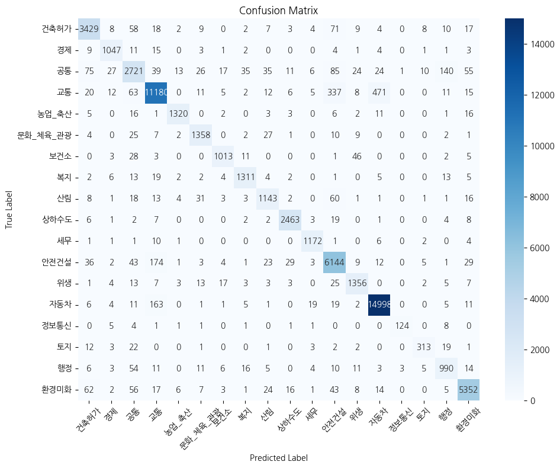

```python
df_pred = pd.read_csv("roberta_val_predictions.csv", encoding="utf-8")

y_true = df_pred["true_label"].values
y_pred = df_pred["pred_label"].values

labels = sorted(list(set(y_true) | set(y_pred)))

cm = confusion_matrix(y_true, y_pred, labels=labels)

plt.figure(figsize=(10, 8))
sns.heatmap(cm, annot=True, fmt="d", cmap="Blues", xticklabels=labels, yticklabels=labels)
plt.xlabel("Predicted Label")
plt.ylabel("True Label")
plt.title("Confusion Matrix")
plt.xticks(rotation=45)
plt.yticks(rotation=0)
plt.tight_layout()
plt.show()
```

### 🎯 성능 요약

- **Accuracy**: `0.9393`
- **Macro F1-score**: `0.92`
- **Weighted F1-score**: `0.94`
- 전반적으로 매우 우수한 성능을 보이며,  
  소수 클래스까지 균형 잡힌 분류 성능을 기록

### 📊 클래스별 성능 분석

- **F1-score 0.90 이상** 클래스:
  - `자동차`, `교통`, `환경미화`, `상하수도`, `세무`, `보건소`, `복지`, `문화_체육_관광` 등
- **소수 클래스도 안정적 성능**:
  - `정보통신`: F1 = 0.90
  - `토지`, `행정`: F1 = 0.86, 0.84
- `공통` 카테고리에서 **약간의 recall 저하** 있음 (81%) → 의미 중복 가능성

### 🧾 혼동 행렬 해석

- 대각선 중심으로 높은 밀도 → **정확한 분류**
- 일부 카테고리(공통, 행정 등)에서 **미세한 클래스 간 혼동** 존재
- 전반적으로 **상위 클래스 간 오예측 매우 적음** → 안정적인 학습 결과

### 📌 종합 평가

| 항목 | 결과 |
| --- | --- |
| Accuracy | 0.9393 |
| Macro F1 | 0.92 |
| 모델 크기 | base |
| 인코딩 방식 | RoBERTa 구조 (token_type_ids 미사용) |

## ⚡️ KcELECTRA (beomi) 분류 성능 평가

### ✅ 모델 정보

- **모델**: `beomi/KcELECTRA-base`
- **입력 길이**: max length = 128
- **Token Type IDs**: 사용 안 함 (ELECTRA 구조)
- **학습 방식**: Hugging Face `Trainer` + EarlyStopping
- **데이터 처리**: 라벨 → `labels`, tokenizer → truncation only

```python
import os
os.environ["CUDA_LAUNCH_BLOCKING"] = "1"

import pandas as pd
import numpy as np
import torch
from sklearn.preprocessing import LabelEncoder
from sklearn.metrics import accuracy_score, classification_report
from datasets import Dataset
from transformers import (
    AutoTokenizer,
    AutoModelForSequenceClassification,
    Trainer,
    TrainingArguments,
    DataCollatorWithPadding,
    EarlyStoppingCallback
)

# 데이터 로딩 및 라벨 인코딩
def load_and_encode_data(train_path, val_path):
    df_train = pd.read_csv(train_path)
    df_val = pd.read_csv(val_path)

    le = LabelEncoder()
    df_train['labels'] = le.fit_transform(df_train['category'])
    df_val['labels'] = le.transform(df_val['category'])

    return df_train, df_val, le

# 토크나이징 함수
def tokenize_dataset(dataset, tokenizer):
    def tokenize_fn(batch):
        return tokenizer(batch['text'], truncation=True, max_length=128)
    return dataset.map(tokenize_fn, batched=True)

# 평가 메트릭
def compute_metrics(eval_pred):
    logits, labels = eval_pred
    preds = np.argmax(logits, axis=-1)
    return {"accuracy": accuracy_score(labels, preds)}

# 메인 실행
def main():
    model_name = "beomi/KcELECTRA-base"
    train_path = "민원통합데이터_train.csv"
    val_path = "민원통합데이터_val.csv"

    # 데이터 로딩 및 변환
    df_train, df_val, le = load_and_encode_data(train_path, val_path)
    dataset_train = Dataset.from_pandas(df_train[['text', 'labels']])
    dataset_val = Dataset.from_pandas(df_val[['text', 'labels']])

    # 토크나이저 및 토큰화
    tokenizer = AutoTokenizer.from_pretrained(model_name, use_fast=True)
    tokenized_train = tokenize_dataset(dataset_train, tokenizer)
    tokenized_val = tokenize_dataset(dataset_val, tokenizer)

    data_collator = DataCollatorWithPadding(tokenizer=tokenizer)

    # 모델 로딩
    model = AutoModelForSequenceClassification.from_pretrained(model_name, num_labels=len(le.classes_))

    # 학습 설정
    training_args = TrainingArguments(
        output_dir="./kcelectra-results",
        eval_strategy="epoch",
        save_strategy="epoch",
        learning_rate=2e-5,
        per_device_train_batch_size=64,
        per_device_eval_batch_size=64,
        num_train_epochs=100,
        weight_decay=0.01,
        load_best_model_at_end=True,
        metric_for_best_model="eval_loss",
        greater_is_better=False,
        logging_dir="./kcelectra-logs",
        fp16=torch.cuda.is_available(),
        dataloader_num_workers=4
    )

    # Trainer 생성
    trainer = Trainer(
        model=model,
        args=training_args,
        train_dataset=tokenized_train,
        eval_dataset=tokenized_val,
        tokenizer=tokenizer,
        compute_metrics=compute_metrics,
        data_collator=data_collator,
        callbacks=[EarlyStoppingCallback(early_stopping_patience=10)]
    )

    # 학습
    trainer.train()

    # 모델 저장
    model.save_pretrained("./kcelectra_final_model")
    tokenizer.save_pretrained("./kcelectra_final_model")

    # 예측
    preds_output = trainer.predict(tokenized_val)
    pred_labels = np.argmax(preds_output.predictions, axis=-1)

    result_df = pd.DataFrame({
        "text": df_val["text"],
        "true_label": df_val["category"],
        "pred_label": le.inverse_transform(pred_labels)
    })
    result_df.to_csv("kcelectra_val_predictions.csv", index=False, encoding="utf-8")

    # 평가 출력
    print(f"\n✅ Accuracy: {accuracy_score(df_val['labels'], pred_labels):.4f}")
    print("\n📊 Classification Report:")
    print(classification_report(df_val['labels'], pred_labels, target_names=le.classes_))

if __name__ == "__main__":
    main()
```

[output not shown]

[output not shown]

[134860/674300 5:13:03 < 20:52:13, 7.18 it/s, Epoch 20/100]

| Epoch | Training Loss | Validation Loss | Accuracy |
| --- | --- | --- | --- |
| 1 | 0.684600 | 0.714369 | 0.778339 |
| 2 | 0.564100 | 0.596320 | 0.816071 |
| 3 | 0.440300 | 0.497856 | 0.848879 |
| 4 | 0.349800 | 0.442363 | 0.868718 |
| 5 | 0.289600 | 0.367688 | 0.894902 |
| 6 | 0.232400 | 0.364258 | 0.902654 |
| 7 | 0.188100 | 0.324671 | 0.915297 |
| 8 | 0.149200 | 0.317427 | 0.922984 |
| 9 | 0.126900 | 0.304011 | 0.925830 |
| 10 | 0.109400 | 0.292230 | 0.933157 |
| 11 | 0.095600 | 0.297204 | 0.934776 |
| 12 | 0.082100 | 0.304675 | 0.937900 |
| 13 | 0.081000 | 0.318989 | 0.936215 |
| 14 | 0.070200 | 0.318069 | 0.940745 |
| 15 | 0.062600 | 0.310365 | 0.942577 |
| 16 | 0.058100 | 0.322057 | 0.942446 |
| 17 | 0.053100 | 0.310737 | 0.944638 |
| 18 | 0.049000 | 0.343853 | 0.943101 |
| 19 | 0.045900 | 0.324140 | 0.946077 |
| 20 | 0.043000 | 0.343704 | 0.945668 |

[output not shown]

[output cut: 589 more lines]

[output not shown]

```
✅ Accuracy: 0.9332

📊 Classification Report:
              precision    recall  f1-score   support

        건축허가       0.91      0.95      0.93      3659
          경제       0.91      0.93      0.92      1102
          공통       0.81      0.82      0.81      3344
          교통       0.95      0.93      0.94     12158
       농업_축산       0.98      0.91      0.95      1386
    문화_체육_관광       0.87      0.94      0.90      1448
         보건소       0.94      0.91      0.93      1112
          복지       0.94      0.91      0.93      1389
          산림       0.88      0.82      0.85      1306
        상하수도       0.96      0.98      0.97      2518
          세무       0.97      0.97      0.97      1199
        안전건설       0.91      0.93      0.92      6519
          위생       0.90      0.93      0.92      1462
         자동차       0.97      0.98      0.97     15246
        정보통신       0.93      0.84      0.89       147
          토지       0.82      0.88      0.85       379
          행정       0.86      0.80      0.83      1152
        환경미화       0.96      0.93      0.95      5617

    accuracy                           0.93     61143
   macro avg       0.92      0.91      0.91     61143
weighted avg       0.93      0.93      0.93     61143
```

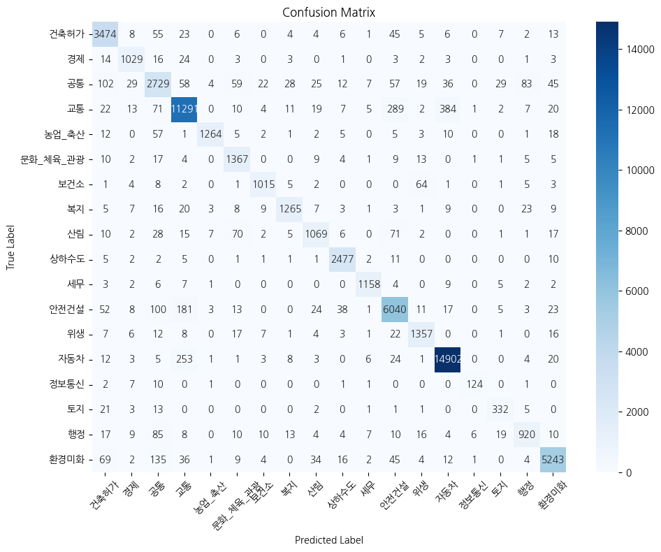

```python
import pandas as pd
import matplotlib.pyplot as plt
import seaborn as sns
from sklearn.metrics import confusion_matrix

df_pred = pd.read_csv("kcelectra_val_predictions.csv", encoding="utf-8")

y_true = df_pred["true_label"].values
y_pred = df_pred["pred_label"].values

labels = sorted(list(set(y_true) | set(y_pred)))

cm = confusion_matrix(y_true, y_pred, labels=labels)

plt.figure(figsize=(10, 8))
sns.heatmap(cm, annot=True, fmt="d", cmap="Blues", xticklabels=labels, yticklabels=labels)
plt.xlabel("Predicted Label")
plt.ylabel("True Label")
plt.title("Confusion Matrix")
plt.xticks(rotation=45)
plt.yticks(rotation=0)
plt.tight_layout()
plt.show()
```

### 🎯 성능 요약

- **Accuracy**: `0.9332`
- **Macro F1-score**: `0.91`
- **Weighted F1-score**: `0.93`
- 전체적으로 매우 높은 성능을 보이며,  
  **클래스 불균형에 대한 견고함**도 우수하게 나타남

### 🧾 혼동 행렬 해석

- 전반적으로 **정확한 대각선 예측**이 잘 이뤄짐
- 일부 클래스 간 오분류(예: 공통 ↔ 교통, 행정 ↔ 복지 등)는 미세 수준
- **소수 클래스도 대부분 안정적 분류**, 실사용 가능성 충분

### 📌 종합 평가

| 항목 | 결과 |
| --- | --- |
| Accuracy | 0.9332 |
| Macro F1 | 0.91 |
| 모델 크기 | base |
| 인코딩 방식 | truncation only |

## ✅ 최종 결론

### 🛠 데이터 전처리 요약

- 원천데이터(`text`)와 라벨링데이터(`category`)를 **ID 기준 inner join**으로 병합하여 정합성 확보
- `text` 기준 중복 제거 및 **최빈 category 기준으로 정제**
- 전처리 후 학습/검증 데이터셋 간 비율 불균형 발생 (Train 97% / Val 2.7%) → **Train 데이터 10% Stratified Sampling하여 Validation에 보강**

### 📊 모델별 성능 비교

[output not shown]

### 🧩 모델 활용 및 연동

- 학습된 KoBERT 모델은 현재 **Hugging Face Spaces에 배포**되어  
  사용자가 민원 텍스트를 입력하면 **실시간으로 카테고리를 분류**.
- 분류된 카테고리를 기반으로 **해당 민원을 처리할 수 있는 정부 부처의 홈페이지와 대표 전화번호**를 제공.